# mnist

# Machine learning in practice

Now that we have learned several methods and explored them with illustrative examples, we are going to try them out on a real example: the MNIST digits.

We can load this data using the following **dslabs** package:

```r
mnist <- read_mnist()
```

The dataset includes two components, a training set and test set:

```r
names(mnist)
```

```
## [1] "train" "test"
```

Each of these components includes a matrix with features in the columns:

```r
dim(mnist$train$images)
```

```
## [1] 60000   784
```

and vector with the classes as integers:

```r
class(mnist$train$labels)
```

```
## [1] "integer"
```

```r
table(mnist$train$labels)
```

```
##
##    0    1    2    3    4    5    6    7    8    9
## 5923 6742 5958 6131 5842 5421 5918 6265 5851 5949
```

This is the vector for the first image in the training set.

```r
mnist$train$images[1,]
```

```
##   [1]   0   0   0   0   0   0   0   0   0   0   0   0   0   0   0   0   0   0
##  [19]   0   0   0   0   0   0   0   0   0   0   0   0   0   0   0   0   0   0
##  [37]   0   0   0   0   0   0   0   0   0   0   0   0   0   0   0   0   0   0
##  [55]   0   0   0   0   0   0   0   0   0   0   0   0   0   0   0   0   0   0
##  [73]   0   0   0   0   0   0   0   0   0   0   0   0   0   0   0   0   0   0
##  [91]   0   0   0   0   0   0   0   0   0   0   0   0   0   0   0   0   0   0
## [109]   0   0   0   0   0   0   0   0   0   0   0   0   0   0   0   0   0   0
## [127]   0   0   0   0   0   0   0   0   0   0   0   0   0   0   0   0   0   0
## [145]   0   0   0   0   0   0   0   0   3  18  18  18 126 136 175  26 166 255
## [163] 247 127   0   0   0   0   0   0   0   0   0   0   0   0  30  36  94 154
## [181] 170 253 253 253 253 253 225 172 253 242 195  64   0   0   0   0   0   0
## [199]   0   0   0   0   0  49 238 253 253 253 253 253 253 253 253 251  93  82
## [217]  82  56  39   0   0   0   0   0   0   0   0   0   0   0   0  18 219 253
## [235] 253 253 253 253 198 182 247 241   0   0   0   0   0   0   0   0   0   0
## [253]   0   0   0   0   0   0   0   0  80 156 107 253 253 205  11   0  43 154
```

[output cut: 29 more lines]

Print the vector in matrix form.

```r
m  <- matrix(mnist$train$images[1,],28,28, byrow=TRUE)
prmatrix(m, rowlab=rep(" ",28), collab=rep("  ",28)) #Print the matrix without row and column indices
```

```
##
##    0  0  0  0   0   0   0   0   0   0   0   0   0   0   0   0   0   0   0   0
##    0  0  0  0   0   0   0   0   0   0   0   0   0   0   0   0   0   0   0   0
##    0  0  0  0   0   0   0   0   0   0   0   0   0   0   0   0   0   0   0   0
##    0  0  0  0   0   0   0   0   0   0   0   0   0   0   0   0   0   0   0   0
##    0  0  0  0   0   0   0   0   0   0   0   0   0   0   0   0   0   0   0   0
##    0  0  0  0   0   0   0   0   0   0   0   0   3  18  18  18 126 136 175  26
##    0  0  0  0   0   0   0   0  30  36  94 154 170 253 253 253 253 253 225 172
##    0  0  0  0   0   0   0  49 238 253 253 253 253 253 253 253 253 251  93  82
##    0  0  0  0   0   0   0  18 219 253 253 253 253 253 198 182 247 241   0   0
##    0  0  0  0   0   0   0   0  80 156 107 253 253 205  11   0  43 154   0   0
##    0  0  0  0   0   0   0   0   0  14   1 154 253  90   0   0   0   0   0   0
##    0  0  0  0   0   0   0   0   0   0   0 139 253 190   2   0   0   0   0   0
##    0  0  0  0   0   0   0   0   0   0   0  11 190 253  70   0   0   0   0   0
##    0  0  0  0   0   0   0   0   0   0   0   0  35 241 225 160 108   1   0   0
```

[output cut: 43 more lines]

This is the 2nd image in the training set.

```r
m<-matrix(mnist$train$images[2,],28,28, byrow=TRUE)
prmatrix(m, rowlab=rep(" ",28), collab=rep("  ",28)) #Print the matrix without row and column indices
```

```
##
##    0  0  0  0  0  0  0   0   0   0   0   0   0   0   0   0   0   0   0   0   0
##    0  0  0  0  0  0  0   0   0   0   0   0   0   0   0   0   0   0   0   0   0
##    0  0  0  0  0  0  0   0   0   0   0   0   0   0   0   0   0   0   0   0   0
##    0  0  0  0  0  0  0   0   0   0   0   0   0   0   0   0   0   0   0   0   0
##    0  0  0  0  0  0  0   0   0   0   0   0   0   0   0  51 159 253 159  50   0
##    0  0  0  0  0  0  0   0   0   0   0   0   0   0  48 238 252 252 252 237   0
##    0  0  0  0  0  0  0   0   0   0   0   0   0  54 227 253 252 239 233 252  57
##    0  0  0  0  0  0  0   0   0   0   0  10  60 224 252 253 252 202  84 252 253
##    0  0  0  0  0  0  0   0   0   0   0 163 252 252 252 253 252 252  96 189 253
##    0  0  0  0  0  0  0   0   0   0  51 238 253 253 190 114 253 228  47  79 255
##    0  0  0  0  0  0  0   0   0  48 238 252 252 179  12  75 121  21   0   0 253
##    0  0  0  0  0  0  0   0  38 165 253 233 208  84   0   0   0   0   0   0 253
##    0  0  0  0  0  0  0   7 178 252 240  71  19  28   0   0   0   0   0   0 253
##    0  0  0  0  0  0  0  57 252 252  63   0   0   0   0   0   0   0   0   0 253
```

[output cut: 43 more lines]

This is the 3nd image in the training set.

```r
m<-matrix(mnist$train$images[3,],28,28, byrow=TRUE)
prmatrix(m, rowlab=rep(" ",28), collab=rep("  ",28)) #Print the matrix without row and column indices
```

```
##
##    0  0  0   0   0   0   0   0   0   0   0   0   0   0   0   0   0   0   0   0
##    0  0  0   0   0   0   0   0   0   0   0   0   0   0   0   0   0   0   0   0
##    0  0  0   0   0   0   0   0   0   0   0   0   0   0   0   0   0   0   0   0
##    0  0  0   0   0   0   0   0   0   0   0   0   0   0   0   0   0   0   0   0
##    0  0  0   0   0   0   0   0   0   0   0   0   0   0   0   0   0   0   0   0
##    0  0  0   0   0   0   0   0   0   0   0   0   0   0   0   0   0   0   0   0
##    0  0  0   0  62  81   0   0   0   0   0   0   0   0   0   0   0   0   0   0
##    0  0  0   0 126 163   0   0   0   0   0   0   0   0   0   0   0   0   0   2
##    0  0  0   0 220 163   0   0   0   0   0   0   0   0   0   0   0   0   0  27
##    0  0  0   0 222 163   0   0   0   0   0   0   0   0   0   0   0   0   0 183
##    0  0  0  46 245 163   0   0   0   0   0   0   0   0   0   0   0   0   0 198
##    0  0  0 120 254 163   0   0   0   0   0   0   0   0   0   0   0   0  23 231
##    0  0  0 159 254 120   0   0   0   0   0   0   0   0   0   0   0   0 163 254
##    0  0  0 159 254  67   0   0   0   0   0   0   0   0   0  14  86 178 248 254
```

[output cut: 43 more lines]

Let’s visualize the first 5 digits in the sample.

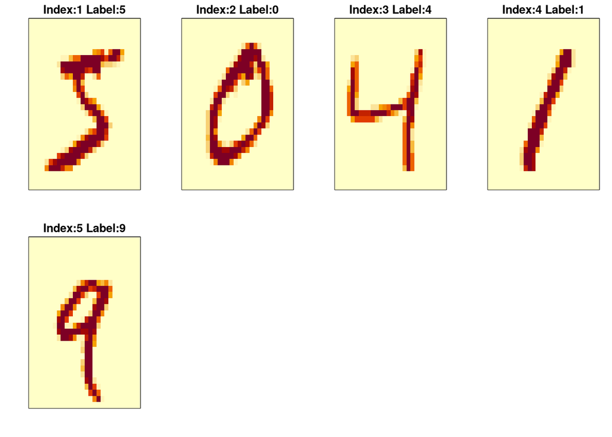

```r
#install.packages(rafalib)
library(rafalib)
rafalib::mypar(2,4)
for(i in 1:5){
  image(matrix(mnist$train$images[i,], 28, 28)[, 28:1],
        main = paste0("Index:",i," Label:", mnist$train$labels[i]),
        xaxt="n", yaxt="n")
}
```

To reduce time time for training and testing, we will sample 10,000 random rows from the training set and 1,000 random rows from the test set:

```r
set.seed(1990)
index <- sample(nrow(mnist$train$images), 10000)
x_train <- mnist$train$images[index,]
y_train <- factor(mnist$train$labels[index])

index <- sample(nrow(mnist$test$images), 1000)
x_test <- mnist$test$images[index,]
y_test <- factor(mnist$test$labels[index])
```

Let’s visualize the digits (the first 10 digits) in the sample.

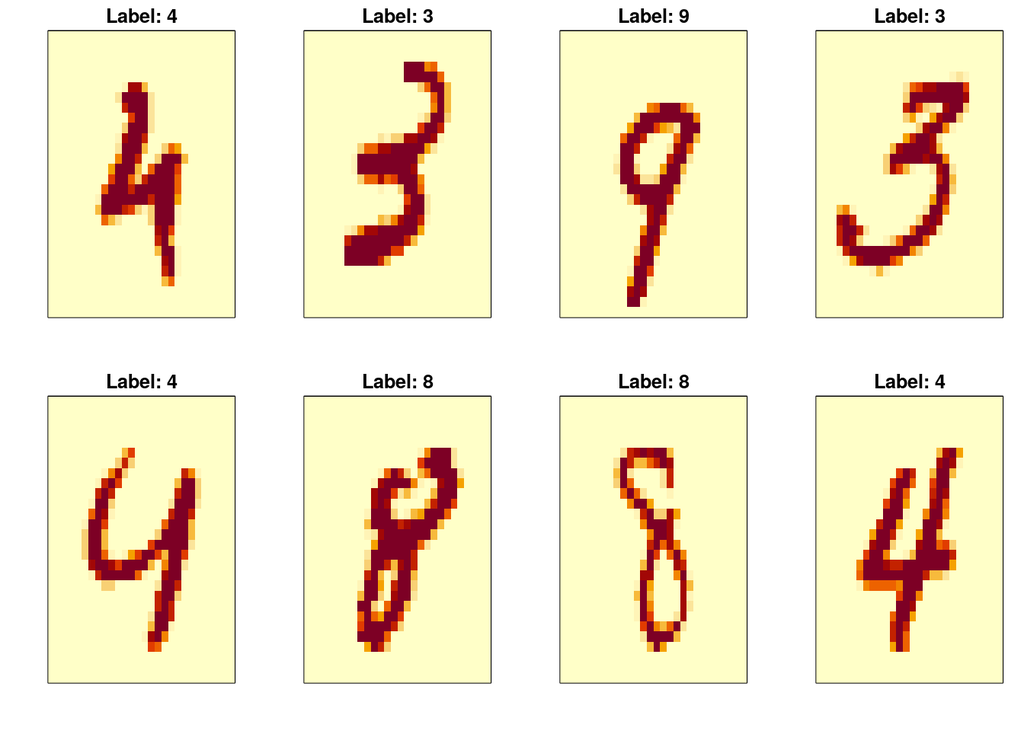

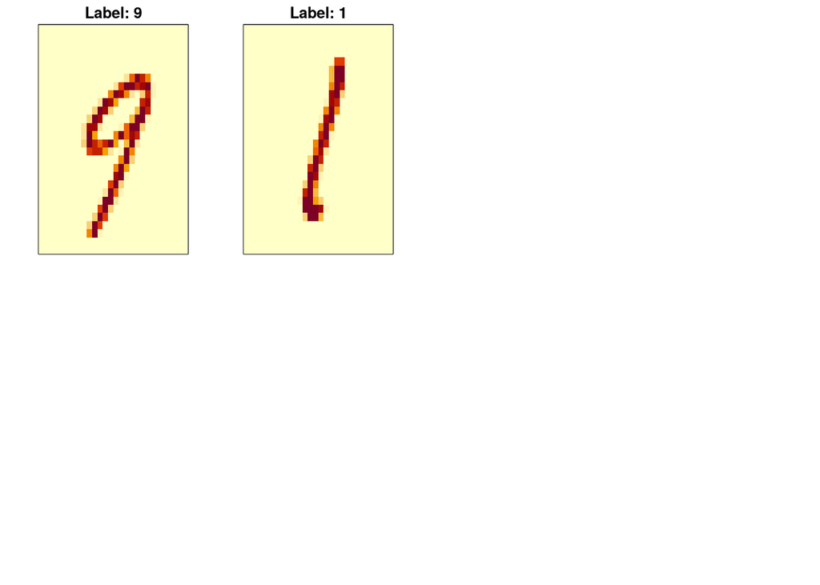

```r
#install.packages(rafalib)
library(rafalib)
rafalib::mypar(2,4) #adjust layout of the plot
for(i in 1:10){
  image(matrix(x_train[i,], 28, 28)[, 28:1],
        main = paste("Label:", y_train[i]),
        xaxt="n", yaxt="n")
}
```

## k-nearest neighbor

Let’s check the arguments of the `knn` function.

```r
library("class")
args(knn)
```

```
## function (train, test, cl, k = 1, l = 0, prob = FALSE, use.all = TRUE)
## NULL
```

We will then run the knn algorithm to predict the labels of the test set. Note that when we run the algorithm, we will have to compute a distance between each observation in the test set and each observation in the training set. There are a lot of computations.

```r
knnresult <- knn(x_train, x_test, y_train)
knnresult #predicted class of the test set
```

```
##    [1] 1 8 2 1 5 8 6 9 9 0 2 1 3 8 7 4 7 1 7 3 6 1 2 5 8 3 0 2 4 1 1 2 1 3 1 5 1
##   [38] 5 3 1 7 5 5 2 5 5 0 2 4 0 8 8 9 2 1 0 6 0 4 4 9 5 9 3 0 4 9 0 9 3 8 8 8 5
##   [75] 9 5 6 5 5 8 1 6 7 1 2 7 4 7 2 0 3 8 1 7 0 4 1 0 8 6 1 1 8 1 4 2 7 3 0 2 6
##  [112] 9 6 1 6 6 7 2 6 1 0 7 1 8 7 8 5 0 5 8 8 4 7 9 0 6 2 9 2 1 3 4 7 4 9 6 7 5
##  [149] 2 5 3 3 7 1 5 9 6 1 3 8 3 5 0 6 5 1 1 9 1 1 5 1 0 1 6 1 1 8 9 0 3 0 9 4 2
##  [186] 7 1 9 5 0 8 4 7 9 2 9 1 1 4 5 7 7 2 9 4 2 1 9 8 6 4 3 4 3 1 1 8 6 8 2 7 3
##  [223] 1 0 1 4 6 7 1 2 8 6 1 5 4 5 9 6 7 6 0 9 9 6 2 6 1 1 5 1 2 3 0 2 5 9 6 3 0
##  [260] 7 8 0 1 9 0 1 3 7 0 6 9 8 9 7 4 7 7 0 9 5 6 1 8 3 4 3 9 8 4 6 3 7 5 2 9 0
##  [297] 5 8 2 2 6 4 7 6 8 7 4 6 7 2 9 6 4 0 7 0 1 9 0 4 7 0 4 0 4 2 4 3 1 3 5 1 3
##  [334] 0 7 6 0 7 9 3 1 5 6 6 0 4 7 1 7 3 0 9 0 5 4 3 7 5 9 0 1 5 7 8 2 3 2 0 9 8
##  [371] 0 5 9 7 1 0 4 2 4 4 4 0 5 4 5 3 2 8 2 1 7 9 1 6 5 1 2 9 1 4 3 0 9 9 8 1 2
##  [408] 9 5 7 1 9 3 6 5 8 2 7 5 2 0 9 3 3 7 6 5 4 7 7 1 9 7 0 6 2 5 3 9 7 0 8 3 1
##  [445] 0 3 4 7 4 3 9 6 1 6 0 3 5 9 0 2 3 1 4 9 8 2 9 8 9 1 7 9 6 2 4 9 1 7 2 4 8
##  [482] 2 8 3 5 9 9 7 3 0 2 3 1 5 5 2 9 1 7 7 6 9 3 6 3 4 3 1 6 1 4 0 5 4 9 1 1 9
##  [519] 3 1 2 8 5 5 5 2 8 2 0 7 6 9 4 2 9 0 7 7 4 8 1 8 0 3 3 9 8 6 7 6 2 6 9 8 1
##  [556] 9 2 7 2 6 1 6 2 6 3 0 8 5 8 4 3 4 0 3 0 8 4 4 9 1 2 3 6 5 2 9 5 3 4 7 2 8
##  [593] 1 9 3 5 7 9 5 9 1 5 0 3 2 1 7 5 0 7 8 6 9 0 2 1 3 5 5 5 0 4 4 0 5 1 0 9 2
##  [630] 7 1 2 1 7 3 8 7 6 0 5 8 8 6 9 0 9 9 1 4 2 5 9 6 0 3 5 9 5 0 6 6 3 8 4 5 7
##  [667] 5 4 6 8 1 9 9 4 5 3 3 9 0 7 3 9 4 4 0 9 0 5 0 3 0 1 2 8 4 7 4 1 9 7 1 4 6
##  [704] 4 3 5 1 5 9 6 6 6 8 3 5 0 5 6 8 7 8 3 0 6 1 0 2 6 3 6 7 3 0 2 7 1 3 0 3 6
##  [741] 9 4 8 3 0 9 0 8 7 8 2 8 8 0 8 4 1 6 5 6 5 1 8 9 3 4 7 3 1 6 3 5 9 5 9 7 9
##  [778] 2 9 2 4 3 4 7 0 7 1 2 3 4 0 3 9 6 0 1 2 2 8 8 1 4 7 7 8 2 1 3 7 7 3 5 8 8
##  [815] 1 6 9 8 5 1 5 7 6 2 4 4 8 1 3 4 1 8 8 8 7 8 1 2 1 5 9 6 2 6 1 9 2 7 4 0 5
##  [852] 9 2 0 7 5 9 6 6 4 0 8 5 1 4 0 3 6 4 3 2 1 4 7 0 7 7 0 1 9 1 4 5 5 4 1 9 5
##  [889] 3 9 9 1 3 0 2 1 0 9 7 6 3 4 9 9 5 7 0 4 2 3 4 5 8 4 0 7 0 3 7 3 5 7 7 8 4
##  [926] 7 3 2 7 7 6 7 1 4 3 7 3 7 8 5 5 6 4 7 3 7 2 7 4 5 9 6 1 7 4 0 1 4 1 8 7 7
##  [963] 4 6 1 7 1 1 0 9 5 6 4 9 0 0 2 3 5 7 9 5 1 4 5 9 4 5 6 0 5 2 3 3 2 7 3 8 6
## [1000] 6
## Levels: 0 1 2 3 4 5 6 7 8 9
```

We can now compare the observed kNN-predicted class and the expected known outcome.

```r
table(knnresult, y_test)
```

```
##          y_test
## knnresult   0   1   2   3   4   5   6   7   8   9
##         0  94   0   2   0   0   1   1   0   3   0
##         1   0 118   0   1   0   0   0   3   1   0
##         2   1   0  82   0   0   1   0   1   1   0
##         3   0   0   0  96   0   0   0   0   3   0
##         4   0   0   0   0  94   1   0   0   1   1
##         5   0   1   0   0   0  93   0   1   6   0
##         6   0   0   0   0   1   3  85   0   0   0
##         7   1   0   2   2   0   1   0 104   0   1
##         8   0   0   0   1   0   0   0   0  82   1
##         9   0   0   0   0   5   1   0   4   0  99
```

Now, we calculate the overall accuracy of our model.

```r
mean(knnresult == y_test)
```

```
## [1] 0.947
```

We can set the number of nearest neighbours that will be considered to assign a class to a new unlabelled observation. By default, the parameter k of the `knn` classifier is 1. Let’s try other k values and compare the accuracy of the model.

```r
knnresult <- knn(x_train, x_test, y_train, k=2)
mean(knnresult == y_test)
```

```
## [1] 0.949
```

Let’s compare the accuracy when k=3.

```r
knnresult <- knn(x_train, x_test, y_train, k=3)
mean(knnresult == y_test)
```

```
## [1] 0.954
```

Let’s compare the accuracy when k=4 and k=5

```r
knnresult <- knn(x_train, x_test, y_train, k=4)
mean(knnresult == y_test)
```

```
## [1] 0.953
```

```r
knnresult <- knn(x_train, x_test, y_train, k=5)
mean(knnresult == y_test)
```

```
## [1] 0.951
```

The confusion matrix is

```r
table(knnresult, y_test)
```

```
##          y_test
## knnresult   0   1   2   3   4   5   6   7   8   9
##         0  96   0   3   0   0   1   1   0   2   0
##         1   0 118   1   0   1   1   1   4   1   0
##         2   0   0  80   0   0   0   0   0   1   0
##         3   0   0   1  96   0   2   0   0   2   0
##         4   0   0   0   1  97   1   0   0   1   0
##         5   0   0   0   1   0  91   0   0   3   1
##         6   0   1   0   0   1   2  84   0   1   0
##         7   0   0   1   2   0   0   0 105   0   2
##         8   0   0   0   0   0   0   0   0  85   0
##         9   0   0   0   0   1   3   0   4   1  99
```

Let’s use the `confusionMatrix` function in the `caret` library.

```r
library(caret)
args(confusionMatrix)
```

```
## function (data, ...)
## NULL
```

```r
cm <- confusionMatrix(knnresult, y_test)
cm
```

```
## Confusion Matrix and Statistics
##
##           Reference
## Prediction   0   1   2   3   4   5   6   7   8   9
##          0  96   0   3   0   0   1   1   0   2   0
##          1   0 118   1   0   1   1   1   4   1   0
##          2   0   0  80   0   0   0   0   0   1   0
##          3   0   0   1  96   0   2   0   0   2   0
##          4   0   0   0   1  97   1   0   0   1   0
##          5   0   0   0   1   0  91   0   0   3   1
##          6   0   1   0   0   1   2  84   0   1   0
##          7   0   0   1   2   0   0   0 105   0   2
##          8   0   0   0   0   0   0   0   0  85   0
##          9   0   0   0   0   1   3   0   4   1  99
##
## Overall Statistics
##
##                Accuracy : 0.951
##                  95% CI : (0.9357, 0.9635)
##     No Information Rate : 0.119
##     P-Value [Acc > NIR] : < 2.2e-16
##
##                   Kappa : 0.9455
##
##  Mcnemar's Test P-Value : NA
##
## Statistics by Class:
##
##                      Class: 0 Class: 1 Class: 2 Class: 3 Class: 4 Class: 5
## Sensitivity            1.0000   0.9916   0.9302   0.9600   0.9700   0.9010
## Specificity            0.9923   0.9898   0.9989   0.9944   0.9967   0.9944
## Pos Pred Value         0.9320   0.9291   0.9877   0.9505   0.9700   0.9479
## Neg Pred Value         1.0000   0.9989   0.9935   0.9956   0.9967   0.9889
## Prevalence             0.0960   0.1190   0.0860   0.1000   0.1000   0.1010
## Detection Rate         0.0960   0.1180   0.0800   0.0960   0.0970   0.0910
## Detection Prevalence   0.1030   0.1270   0.0810   0.1010   0.1000   0.0960
## Balanced Accuracy      0.9961   0.9907   0.9646   0.9772   0.9833   0.9477
##                      Class: 6 Class: 7 Class: 8 Class: 9
## Sensitivity            0.9767   0.9292   0.8763   0.9706
## Specificity            0.9945   0.9944   1.0000   0.9900
## Pos Pred Value         0.9438   0.9545   1.0000   0.9167
## Neg Pred Value         0.9978   0.9910   0.9869   0.9966
## Prevalence             0.0860   0.1130   0.0970   0.1020
## Detection Rate         0.0840   0.1050   0.0850   0.0990
## Detection Prevalence   0.0890   0.1100   0.0850   0.1080
## Balanced Accuracy      0.9856   0.9618   0.9381   0.9803
```

The accuracy of the model is

```r
cm$overall["Accuracy"]
```

```
## Accuracy
##    0.951
```

```r
cm$byClass[,1:2]
```

```
##          Sensitivity Specificity
## Class: 0   1.0000000   0.9922566
## Class: 1   0.9915966   0.9897843
## Class: 2   0.9302326   0.9989059
## Class: 3   0.9600000   0.9944444
## Class: 4   0.9700000   0.9966667
## Class: 5   0.9009901   0.9944383
## Class: 6   0.9767442   0.9945295
## Class: 7   0.9292035   0.9943630
## Class: 8   0.8762887   1.0000000
## Class: 9   0.9705882   0.9899777
```

## Visual assessments

An important part of data analysis is visualizing results to determine why we are failing. We can show the images of digits for which we made an incorrect prediction.

Here are some errors for kNN

```
##  [1]   2  36  39 110 150 161 179 195 239 253 289 296 304 331 338 362 380 390 409
## [20] 442 451 473 479 480 494 546 580 613 617 639 659 693 701 716 717 746 772 809
## [39] 837 848 876 906 907 915 919 930 964 971 986
```

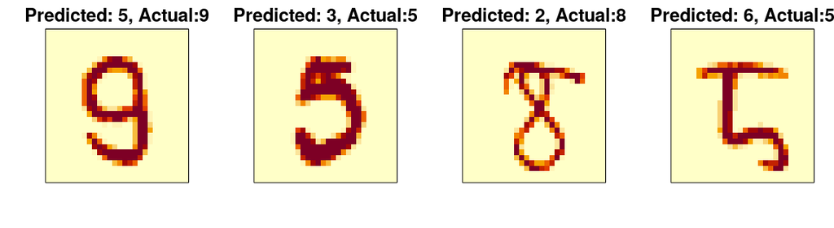

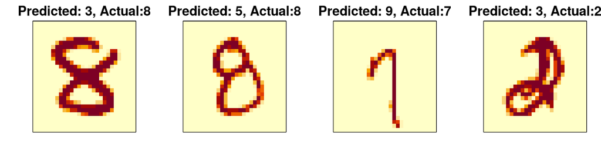

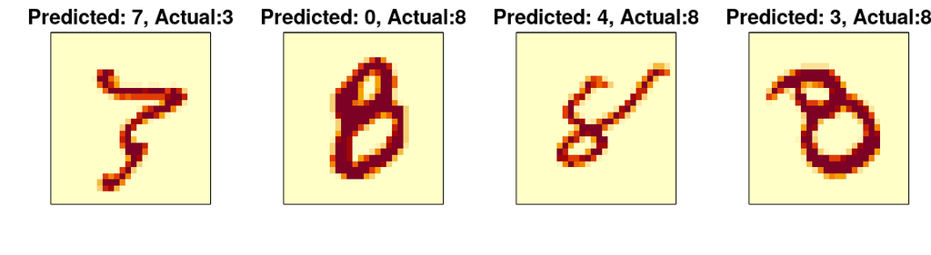

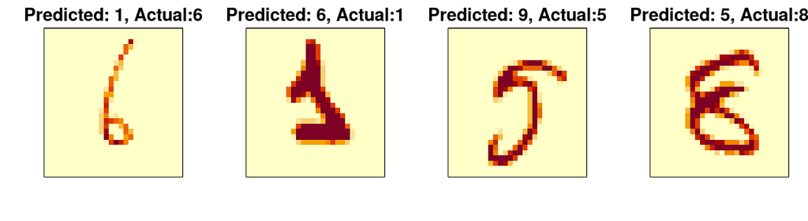

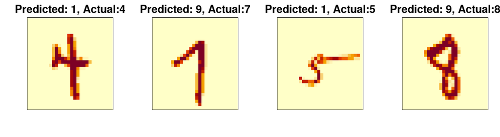

By examining errors like this we often find specific weaknesses to algorithms or parameter choices and can try to correct them.

## References

- https://rafalab.github.io/dsbook/introduction-to-machine-learning.html
- https://bradleyboehmke.github.io/HOML/knn.html#knn-mnist
- https://rafalab.github.io/dsbook/introduction-to-machine-learning.html#two-or-seven
- https://rafalab.github.io/dsbook/machine-learning-in-practice.html